# Forecasting

Federica Fiorentini - 807124

```r
list.of.packages <- c("xts", "forecast", "tseries", "ggplot2", "urca", "tsoutliers", "fpp2", "timeSeries", "KFAS", "tidyverse", "glue", "forcats", "timetk", "tidyquant", "tibbletime", "cowplot", "recipes", "rsample", "yardstick", "keras", "dplyr", "skmeans", "tsfknn")
new.packages <- list.of.packages[!(list.of.packages %in% installed.packages()[,"Package"])]
if(length(new.packages)) install.packages(new.packages)

library(xts)
library(forecast)
library(tseries)
library(ggplot2)
library(urca)
library(tsoutliers)
library(fpp2)
library(timeSeries)
library(KFAS)
library(tidyverse)
library(glue)
library(forcats)
library(timetk)
library(tidyquant)
library(tibbletime)
library(cowplot)
library(recipes)
library(rsample)
library(yardstick)
library(keras)
library(forecast)
library(dplyr)
library(skmeans)
library(tsfknn)
```

# Introduzione, dati e pre-processing

Lo scopo del progetto è di prevedere l’andamento della serie storica in considerazione riguardante i prezzi dell’energia elettrica. I dati forniti si riferiscono ad un periodo dal 1-gen-2010 al 31-dec-2018 e sono aggregati a livello giornaliero. La previsione viene effettuata dal 1-gen-2019 al 30-nov-2019.

```r
#caricamento del dataset e trasformazione della variabile data in formato date
df <- read.csv("C:/Users/FedericaFiorentini/Desktop/time_series_dataset.csv", sep=";")
df$Data <- as.Date(df$Data)
```

Il dataset è costituito da due colonne: Data e Value, corrispondente al valore del prezzo dell’energia.

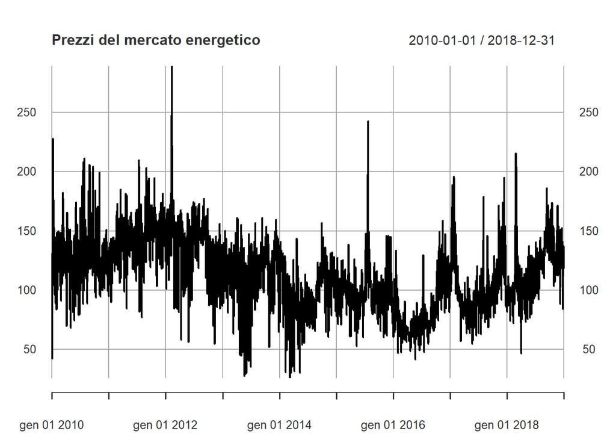

```r
plot(xts(df$value, df$Data, frequency = 7), main = 'Prezzi del mercato energetico')
```

Da una prima visualizzazione della serie storica emerge una possibile stagionalità settimanale, abbastanza prevedibile se si pensa al mercato di riferimento dei dati. Il processo, inoltre, sembra essere stazionario in varianza poiché, escludendo alcuni picchi, il sembra non si presentino particolari trend crescenti o decrescenti. I picchi possono risultare in corrispondenza di festività o del weekend, come detto in precedenza, oppure in presenza di outlier.

Di seguito vengono effettuate alcune analisi per capire l’andamento della serie e i possibili cambiamenti durante la settimana.

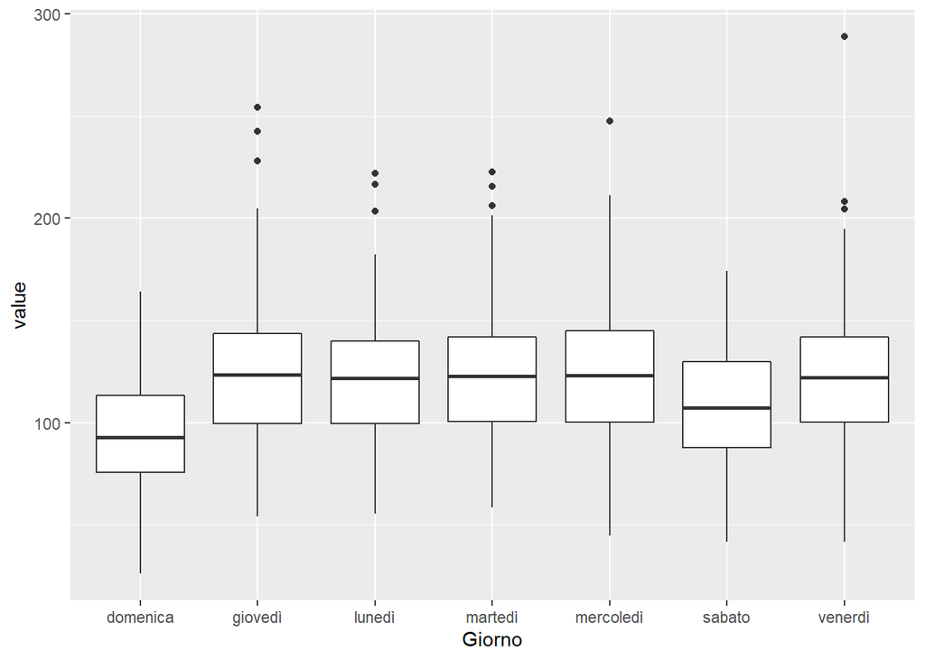

```r
df$Giorno <- as.factor(strftime(df$Data, format = '%A'))
ggplot(df, aes(Giorno, value)) + geom_boxplot() + xlab('Giorno')
```

Anche questo grafico conferma la differenza del consumo di energia elettrica tra i giorni della settimana. Mediamente, infatti, la domenica si rileva un consumo più basso così come il sabato, a differenza degli altri giorni in cui all’incirca mantiene lo stesso livello. Come evidenziano i boxplot, inoltre, sono presenti diversi outlier, di seguito analizzati.

```r
outliers <- tsoutliers(df$value)
n_out <- length(outliers$index)
n_out
```

```
## [1] 26
```

```r
df$value <- tsclean(df$value)
```

```r
#trasformazione ts e split in train e validation
df_ts = xts(df$value, order.by = df$Data)


df_train <- df_ts["2010-01-01/2017-06-30"]
df_validation <- df_ts["2017-07-01/2018-12-31"] #!è stato cambiato per provavalidation <- idata["2017-07-01/2018-12-31"]
```

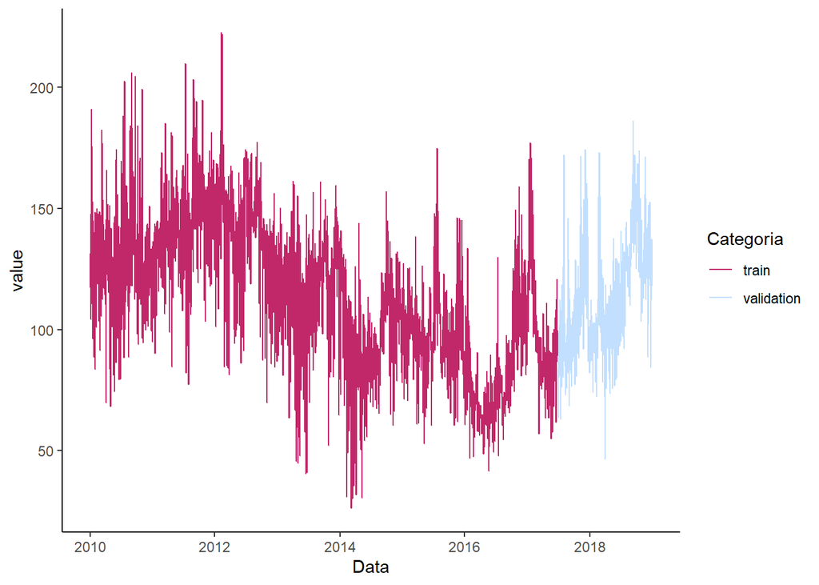

```r
#rappresentazione della serie suddivisa in train e validation
df$Categoria <- ifelse(df$Data > "2017-06-30","validation", "train")
ggplot(df, aes(x = Data,y = value)) +
        geom_line(aes(colour = Categoria)) +
  scale_color_manual(values = c("#C12869", "#C2DFFF")) +
  theme_classic()
```

# Sviluppo’dei modelli

Di seguito lo sviluppo di diversi modelli appartenenti a 3 categorie:

- Modelli **ARIMA** (AutoRegressive Integrated Moving Average);
  - Modelli **UCM** (modelli a componenti non osservabili);
  - **Modelli non-lineari** (ML)

# ARIMA

Per stimare i coefficienti del modello ARIMA è stata seguita la procedura di Box e Jenkins che prevede, inizialmente, l’analisi dei correlogrammi della serie per stimare i coefficienti stagionali e non sia della parte autoregressiva che quella a media mobile.

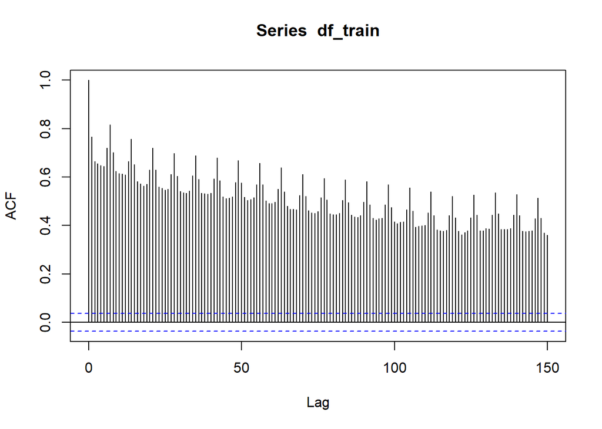

```r
#acf e pacf plot
acf(df_train, lag.max = 150)
```

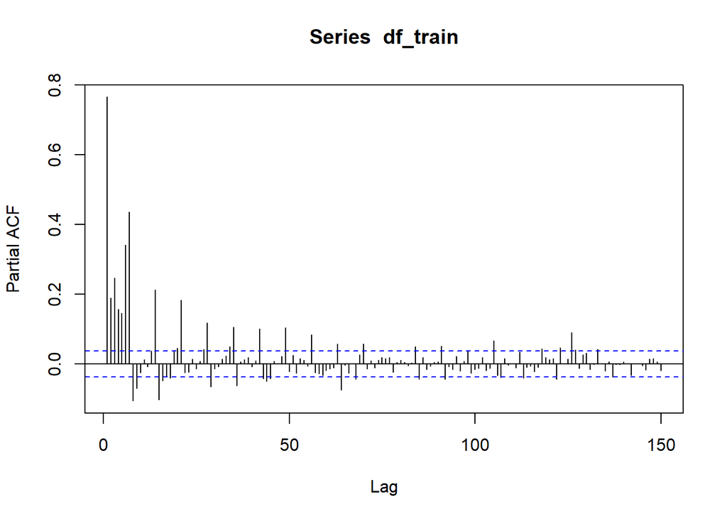

```r
pacf(df_train, lag.max = 150)
```

Osservando i correlogrammi della serie, si osserva che l’ACF tende a zero molto lentamente. Si evince, inoltre, l’evidenza di picchi con cadenza settimanale e questo va a confermare la presenza di una leggera *non stazionarietà in media*. Si procede, quindi, con una differenziazione settimanale e, successivamente, con l’applicazione di un primo modello ARIMA.

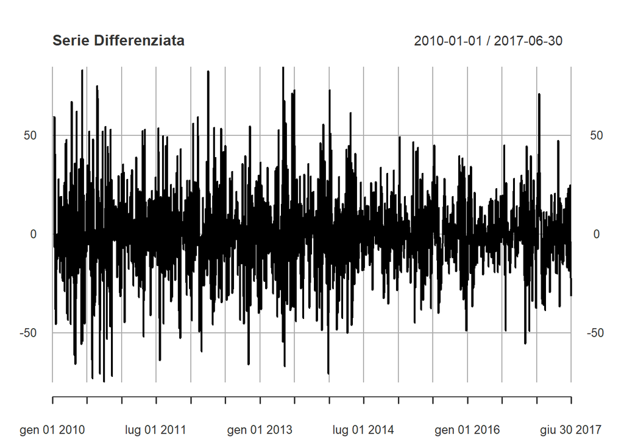

```r
#differenziazione settimanale
df_train_diff7 <- diff(df_train,7)
plot(df_train_diff7, main = "Serie Differenziata")
```

### ARIMA semplice

Dal grafico, la serie sembra essere stazionaria in media poiché i valori oscillano tutti intorno allo zero. Si procede come detto in precedenza al calcolo del modello:
$$ARIMA (0,0,0) (1,1,1)_7$$
Si pone il parametro lambda=auto per permettere di stimare il coefficiente utile alla trasformazione di Box-Cox per rendere la serie stazionaria in varianza.

```r
#modello ARIMA
mod_1 <- Arima(df_train_diff7, c(0,0,0), list(order = c(1,0,1), period = 7), lambda = "auto" )
mod_1
```

```
## Series: df_train_diff7
## ARIMA(0,0,0)(1,0,1)[7] with non-zero mean
## Box Cox transformation: lambda= 0.8595587
##
## Coefficients:
##         sar1     sma1     mean
##       0.2997  -0.7827  -1.2801
## s.e.  0.0313   0.0214   0.0714
##
## sigma^2 estimated as 142.4:  log likelihood=-10646.84
## AIC=21301.69   AICc=21301.7   BIC=21325.34
```

Come suggerisce la procedura di Box e Jenkins, si effettua l’analisi dei residui del modello.

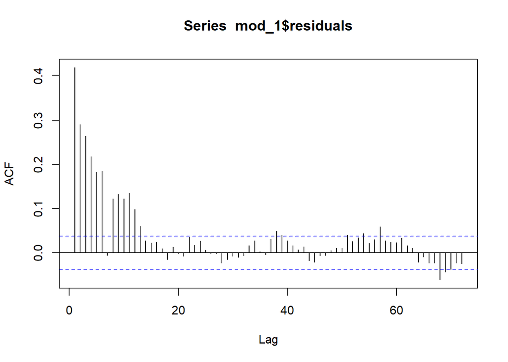

```r
Acf(mod_1$residuals, lag.max = 72)
```

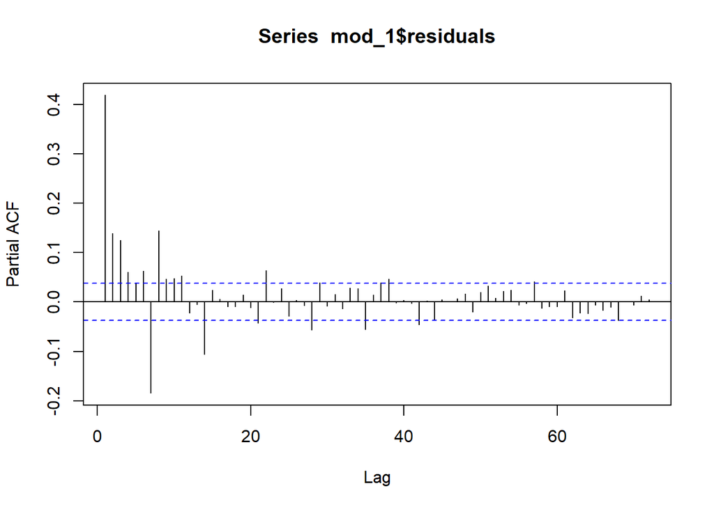

```r
Pacf(mod_1$residuals, lag.max = 72)
```

Dai correlogrammi dei residui, si nota che la PACF rimane significativa nei primi 6 ritardi. Si cerca il coefficiente della parte autoregressiva non stagionale testando 7 modelli di ordine da 0 a 6. Il modello migliore viene selezionato tramite il criterio dell’AIC, ovvero il modello che minimizza questo valore. Si preferisce non aumentare ancor di più il valore del coefficiente dell’AR (anche se in realtà al ritardo 7 rimane ancora significativo) perché, a fronte di un piccolo miglioramento del modello, si preferisce non appesantirlo con troppi coefficienti. Inoltre, la significatività del ritardo 7 potrebbe essere dovuta a rimanenze della componente stagionale.

```r
#stima dei modelli ARIMA

for (i in 0:6) {
  mod <- Arima(df_train_diff7, c(i,0,0), list(order=c(1,0,1), period=7),lambda = "auto")
  print(paste0("AR-", i," MA-0"," AIC: ",round(mod$aic)))
}
```

```
## [1] "AR-0 MA-0 AIC: 21302"
## [1] "AR-1 MA-0 AIC: 20671"
## [1] "AR-2 MA-0 AIC: 20590"
## [1] "AR-3 MA-0 AIC: 20513"
## [1] "AR-4 MA-0 AIC: 20486"
## [1] "AR-5 MA-0 AIC: 20474"
## [1] "AR-6 MA-0 AIC: 20426"
```

Il modello migliore sembra essere
$$ARIMA(6,0,0)(1,0,1)_7$$

```r
#stima del modello migliore
best_mod = Arima(df_train, c(6,0,0), list(order=c(1,1,1), period=7),lambda = "auto")
best_mod
```

```
## Series: df_train
## ARIMA(6,0,0)(1,1,1)[7]
## Box Cox transformation: lambda= 1.004356
##
## Coefficients:
##          ar1     ar2     ar3     ar4     ar5     ar6    sar1     sma1
##       0.3851  0.0815  0.1199  0.0775  0.0309  0.1628  0.0966  -0.9673
## s.e.  0.0190  0.0204  0.0203  0.0203  0.0203  0.0194  0.0208   0.0062
##
## sigma^2 estimated as 198.4:  log likelihood=-11103.14
## AIC=22224.29   AICc=22224.36   BIC=22277.5
```

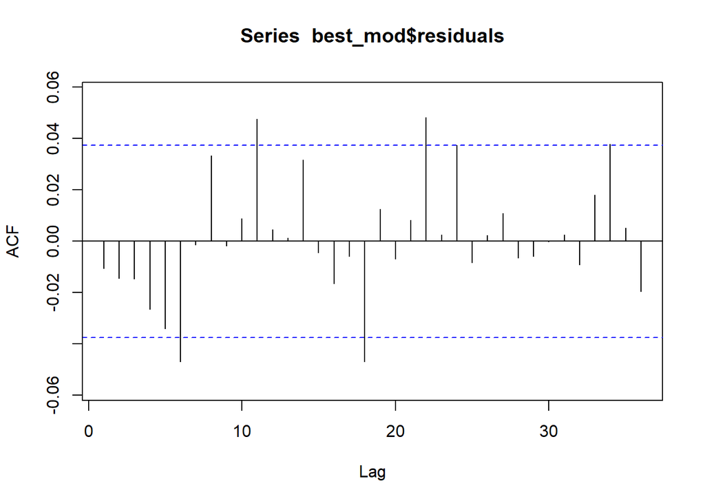

```r
#analisi dei residui
Acf(best_mod$residuals, lag.max = 36)
```

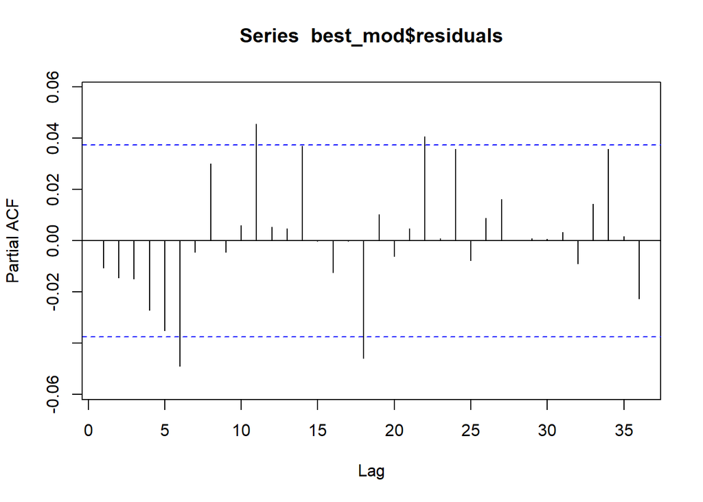

```r
Pacf(best_mod$residuals, lag.max = 36)
```

```r
previsioni <- forecast::forecast(best_mod, h=549)
```

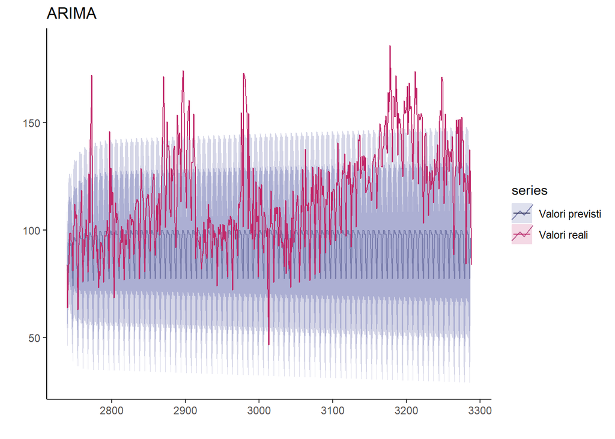

```r
#Previsioni rispetto ai valori reali
graph_arima <- ggplot(ts(df_train["2010-01-01/2017-06-30"], start = 1, end = 2, frequency = frequency(df_train) )) +
  autolayer(previsioni,series="Valori previsti") +
  autolayer(ts(df_validation, start =length(df_train)+1, end = length(df_validation)+length(df_train)+1,frequency = frequency(df_validation)), series="Valori reali") +
  scale_color_manual(values = c("#252850", "#C12869")) +
  theme_classic() +
  xlab(" ") +
  ylab(" ") +
  ggtitle("ARIMA")

graph_arima
```

Dal grafico si osserva che i valori della previsione rispetto ai valori reali non sono ottimali. Questo perché il modello ARIMA non riesce a cogliere la multistagionalità intra annua e settimanale. Al modello, quindi, vengono aggiunti inizialmente solamente dei regressori sinusoidali che permettono di catturare la stagionalità intra-annua. In particolare, sono state considerate le prime 20 serie di regressori sinusoidali che permettono di stimare stagionalità lisce. La frequenza è pari a $2\pi/365.25$. Successivamente sono stati introdotti dei regressori dummy in prossimità delle feste italiane: Capodanno, Epifania, Pasqua, 25 Aprile, 1 Maggio, 2 Giugno, Ferragosto, Santi, Immacolata e Natale.

### ARIMA con regressori sinusoidali

```r
#creazione delle dummy
freq <- outer(1:nrow(df)+334, 1:20)*2*pi/365.25
cs   <- cos(freq)
colnames(cs) <- paste("cos", 1:20)
si   <- sin(freq)
colnames(si) <- paste("cos", 1:20)
sin <- as.matrix(cbind(cs,si))

#Modello con regressori sinosoidali
best_mod_reg <- Arima(df_train, c(6,0,0), list(order = c(1,1,1), period = 7),xreg=sin[1:(length(df_train)),] )
best_mod_reg
```

```
## Series: df_train
## Regression with ARIMA(6,0,0)(1,1,1)[7] errors
##
## Coefficients:
##          ar1     ar2     ar3     ar4     ar5     ar6    sar1     sma1   cos 1
##       0.3559  0.0648  0.1083  0.0729  0.0311  0.1706  0.0927  -0.9585  0.0936
## s.e.  0.0191  0.0202  0.0201  0.0202  0.0202  0.0196  0.0211   0.0079  2.0793
##        cos 2   cos 3    cos 4   cos 5   cos 6   cos 7    cos 8    cos 9
##       3.3003  0.4170  -0.5068  2.0140  0.6784  2.4534  -0.7660  -1.1215
## s.e.  1.8554  1.6585   1.4670  1.2961  1.1516  1.0310   0.9295   0.8428
##        cos 10   cos 11   cos 12   cos 13  cos 14  cos 15  cos 16   cos 17
##       -0.0099  -1.8240  -0.2907  -1.3518  0.5638  0.0618  0.7365  -0.0897
## s.e.   0.7685   0.7053   0.6517   0.6061  0.5667  0.5322  0.5018   0.4755
##       cos 18   cos 19   cos 20    cos 1    cos 2   cos 3    cos 4   cos 5
##       0.6755  -0.0093  -1.0193  -9.4835  -0.0605  0.6557  -1.6929  2.7650
## s.e.  0.4527   0.4331   0.4156   2.0968   1.8455  1.6475   1.4641  1.2997
##         cos 6   cos 7    cos 8   cos 9   cos 10   cos 11  cos 12  cos 13
##       -1.0262  1.0466  -3.1843  0.6207  -0.8265  -0.2292  0.4141  0.9080
## s.e.   1.1556  1.0319   0.9277  0.8409   0.7682   0.7063  0.6528  0.6062
##       cos 14   cos 15  cos 16  cos 17  cos 18   cos 19   cos 20
##       1.3662  -0.3604  0.4510  0.3002  0.3352  -1.1098  -0.0400
## s.e.  0.5660   0.5315  0.5019  0.4760  0.4531   0.4330   0.4152
##
## sigma^2 estimated as 187.5:  log likelihood=-11005.33
## AIC=22108.66   AICc=22110.49   BIC=22398.37
```

```r
previsioni_reg <- forecast::forecast(best_mod_reg, h=549,
              xreg=sin[(length(df_train)+1):(length(df_train)+549),])
```

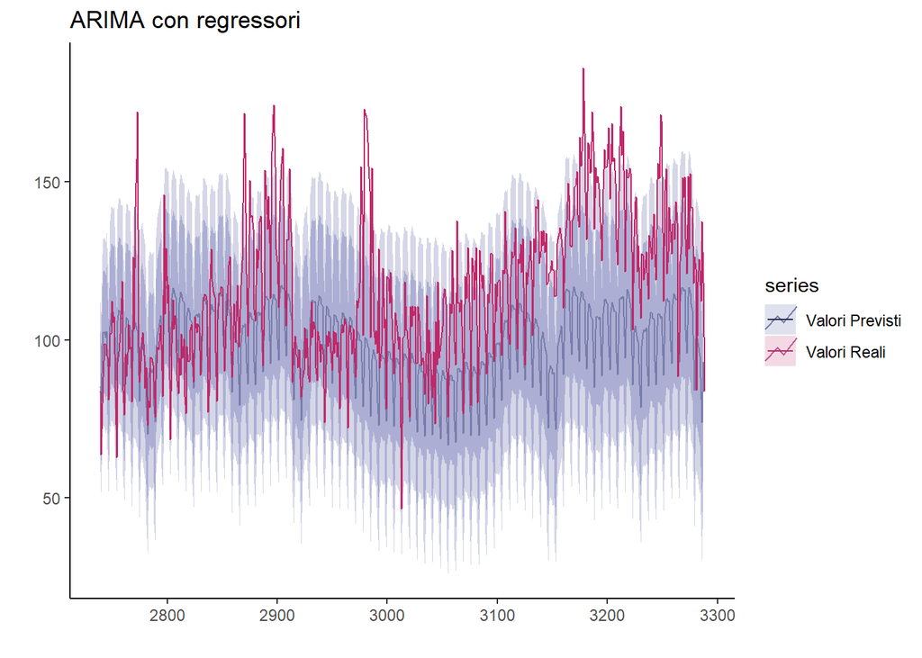

```r
graph_reg <- ggplot(ts(df_train["2010-01-01/2017-06-30"], start = 1, end = 2, frequency = frequency(df_train) )) +
  autolayer(previsioni_reg,series="Valori Previsti") +
  autolayer(ts(df_validation, start =length(df_train)+1, end = length(df_validation)+length(df_train)+1,frequency = frequency(df_validation)), series="Valori Reali") +
  scale_color_manual(values = c("#252850", "#C12869")) +
  theme_classic() +
  xlab(" ") +
  ylab(" ") +
  ggtitle("ARIMA con regressori")

graph_reg
```

Da una prima valutazione qualitativa, la previsione risulta essere decisamente migliore rispetto al modello ARIMA senza regressori. Vengono aggiunte anche le dummy in prossimità delle feste.

### ARIMA con regressori sinusoidali e dummy festività

```r
timeDate::listHolidays("IT")
```

```
## [1] "ITAllSaints"              "ITAssumptionOfVirginMary"
## [3] "ITEpiphany"               "ITImmaculateConception"
## [5] "ITLiberationDay"          "ITStAmrose"
```

```r
capodanno <- as.Date(NewYearsDay(2010:2018))
epifania <- as.Date(ITEpiphany(2010:2018))
pasqua <- as.Date(c(Easter(2010:2018), EasterMonday(2010:2018)))
aprile_25 <- as.Date(ITLiberationDay(2010:2018))
maggio_1 <- as.Date(LaborDay(2010:2018))
giugno_2 <- as.Date(paste0(2010:2018,"-06-02"))
ferragosto <- as.Date(paste0(2010:2018,"-08-15"))
santi <- as.Date(ITAllSaints(2010:2018))
immaccolata <- as.Date(ITImmaculateConception(2010:2018))
natale <- as.Date(c(ChristmasDay(2010:2018), ChristmasEve(2010:2018)))
ultimo_anno <- as.Date(paste0(2010:2018,"-12-31"))
```

```r
data.frame(Data=df$Data) %>%
    mutate(Capodanno = as.numeric(Data %in% capodanno)) %>%
    mutate(Epifania = as.numeric(Data %in% epifania)) %>%
    mutate(Pasqua = as.numeric(Data %in% pasqua)) %>%
    mutate(Liberazione = as.numeric(Data %in% aprile_25)) %>%
    mutate(Lavoratori = as.numeric(Data %in% maggio_1)) %>%
    mutate(Unita = as.numeric(Data %in% giugno_2)) %>%
    mutate(Ferragosto = as.numeric(Data %in% ferragosto)) %>%
    mutate(Santi = as.numeric(Data %in% santi)) %>%
    mutate(Immaccolata = as.numeric(Data %in% immaccolata)) %>%
    mutate(Natale = as.numeric(Data %in% natale)) %>%
    mutate(Ultimo = as.numeric(Data %in% ultimo_anno)) %>%
    select(-starts_with("Data")) %>%
    as.matrix() -> fest
```

```r
all_reg <- as.matrix(cbind(sin,fest))
```

```r
best_mod_reg_dum <- Arima(df_train, c(6,0,0), list(order=c(1,1,1), period=7),
              xreg=all_reg[1:(length(df_train)),], include.constant = TRUE, lambda = "auto")
best_mod_reg_dum
```

```
## Series: df_train
## Regression with ARIMA(6,0,0)(1,1,1)[7] errors
## Box Cox transformation: lambda= 1.004356
##
## Coefficients:
##          ar1     ar2     ar3     ar4     ar5     ar6    sar1     sma1    drift
##       0.4020  0.0585  0.1043  0.0588  0.0257  0.1509  0.1310  -0.9626  -0.0157
## s.e.  0.0193  0.0207  0.0206  0.0208  0.0209  0.0199  0.0215   0.0078   0.0084
##        cos 1   cos 2   cos 3    cos 4   cos 5   cos 6   cos 7    cos 8    cos 9
##       0.1881  2.7452  0.2747  -0.1824  2.0355  0.2531  2.1300  -0.5703  -0.9178
## s.e.  2.0641  1.8741  1.6953   1.5156  1.3488  1.2041  1.0788   0.9728   0.8816
##        cos 10   cos 11  cos 12   cos 13  cos 14  cos 15  cos 16  cos 17  cos 18
##       -0.6089  -2.0579  0.3431  -0.8655  0.3332  0.1099  0.8531  0.0498  0.4825
## s.e.   0.8037   0.7355  0.6781   0.6287  0.5871  0.5497  0.5172  0.4881  0.4650
##        cos 19   cos 20  cos 1.1  cos 2.1  cos 3.1  cos 4.1  cos 5.1  cos 6.1
##       -0.3323  -1.0008  -9.3561  -0.3445   0.1625  -1.9031   2.7332  -0.7440
## s.e.   0.4429   0.4253   2.0802   1.8644   1.6858   1.5125   1.3518   1.2066
##       cos 7.1  cos 8.1  cos 9.1  cos 10.1  cos 11.1  cos 12.1  cos 13.1
##        1.0621  -3.4239   0.7581   -0.2886   -0.2444    0.3782    1.1133
## s.e.   1.0811   0.9725   0.8806    0.8020    0.7364    0.6789    0.6292
##       cos 14.1  cos 15.1  cos 16.1  cos 17.1  cos 18.1  cos 19.1  cos 20.1
##         1.4654   -0.4844    0.0603   -0.0322    0.4669   -0.7829   -0.4099
## s.e.    0.5853    0.5485    0.5167    0.4899    0.4642    0.4441    0.4243
##       Capodanno  Epifania    Pasqua  Liberazione  Lavoratori     Unita
##        -11.8438  -24.3866  -12.4213     -32.7827    -38.5322  -24.8031
## s.e.     4.5541    4.2624    3.5345       4.2625      4.2451    4.2255
##       Ferragosto     Santi  Immaccolata   Natale   Ultimo
##         -13.2266  -31.4792     -14.3618  -0.6616  -3.1913
## s.e.      4.5125    4.5329       4.5245   3.9742   4.9164
##
## sigma^2 estimated as 178:  log likelihood=-10928.04
## AIC=21978.08   AICc=21980.91   BIC=22338.74
```

```r
previsioni_reg_dum <- forecast::forecast(best_mod_reg_dum, h=549,
              xreg=all_reg[(length(df_train)+1):(length(df_train)+549),])
```

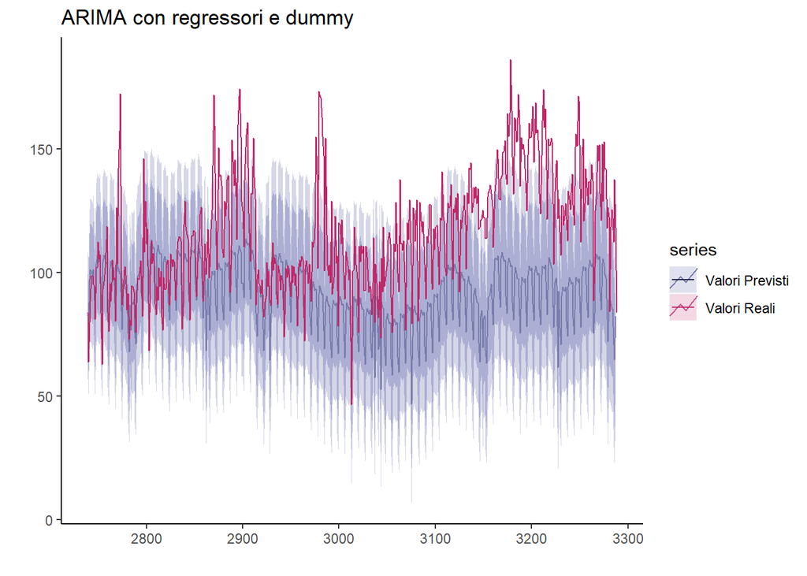

```r
reg_dum <- ggplot(ts(df_train["2010-01-01/2017-06-30"], start = 1, end = 2, frequency = frequency(df_train) )) +
  autolayer(previsioni_reg_dum,series="Valori Previsti") +
  autolayer(ts(df_validation, start =length(df_train)+1, end = length(df_validation)+length(df_train)+1,frequency = frequency(df_validation)), series="Valori Reali") +
  scale_color_manual(values = c("#252850", "#C12869")) +
  theme_classic() +
  xlab(" ") +
  ylab(" ") +
  ggtitle("ARIMA con regressori e dummy")

reg_dum
```

### Confronto tra i 3 modelli ARIMA

```r
print(paste0("ARIMA: ", round(best_mod$aic)))
```

```
## [1] "ARIMA: 22224"
```

```r
print(paste0("ARIMA con regressori: ", round(best_mod_reg$aic)))
```

```
## [1] "ARIMA con regressori: 22109"
```

```r
print(paste0("ARIMA con regressori e dummy: ", round(best_mod_reg_dum$aic)))
```

```
## [1] "ARIMA con regressori e dummy: 21978"
```

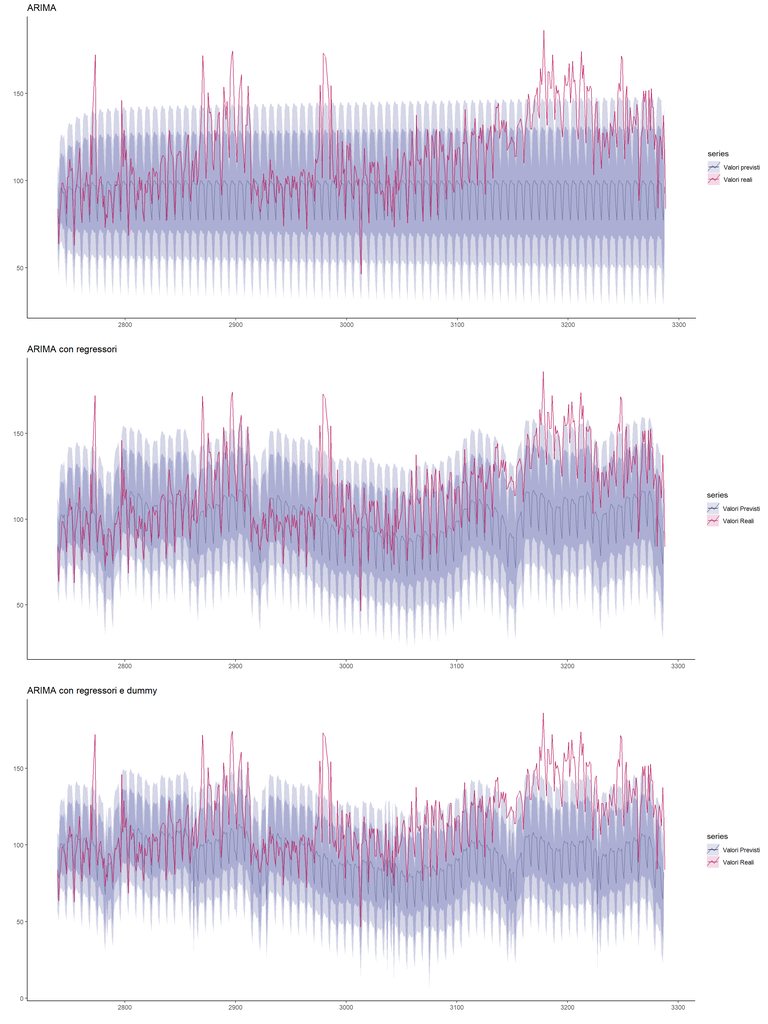

```r
gridExtra::grid.arrange(graph_arima, graph_reg, reg_dum)
```

Sia da una analisi qualitativa dei grafici, sia dal confronto dell’AIC dei 3 modelli ARIMA sviluppati, emerge che il modello migliore è il modello $ARIMA(6,0,0)(1,1,1)_7$ sia con i regressori sinusoidali che le dummy relative alle festività. Per concludere la procedura di Box-Jenkins, si analizzano i residui del modello risultato migliore.

### Analisi dei residui

I residui di un modello ARIMA devono rispettare 3 ipotesi fondamentali: - Normalità - Media nulla - Incorrelati

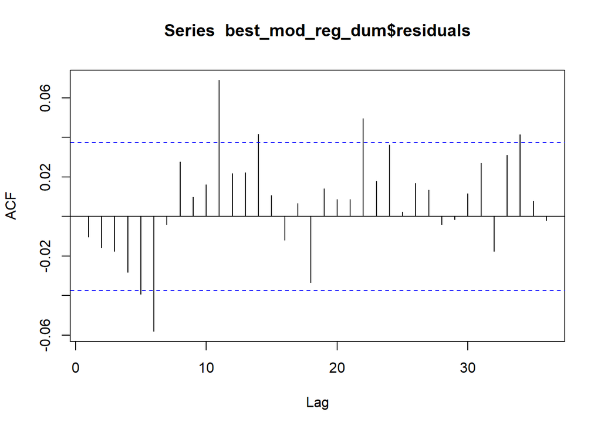

```r
Acf(best_mod_reg_dum$residuals, lag.max = 36)
```

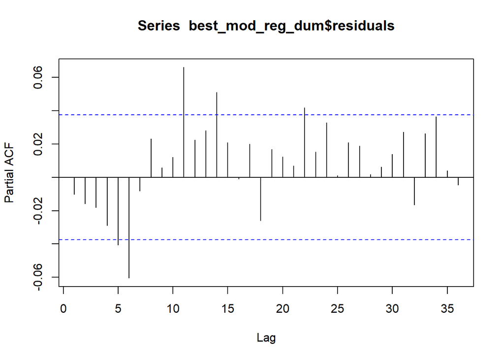

```r
Pacf(best_mod_reg_dum$residuals, lag.max = 36)
```

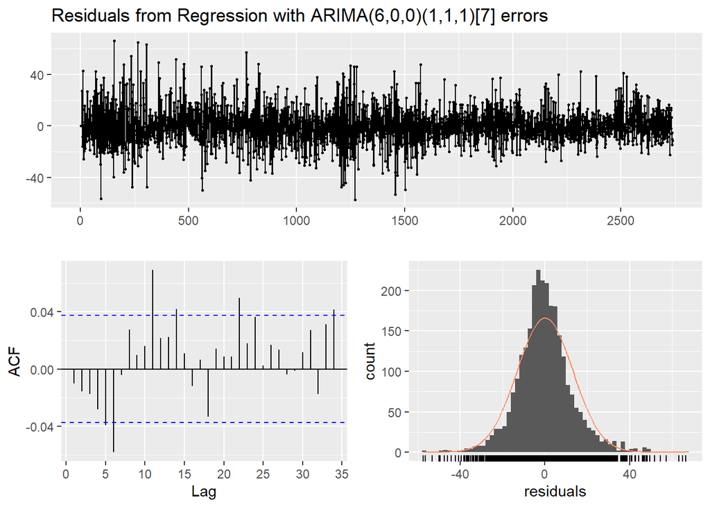

```
##
##  Ljung-Box test
##
## data:  Residuals from Regression with ARIMA(6,0,0)(1,1,1)[7] errors
## Q* = 105.8, df = 3, p-value < 2.2e-16
##
## Model df: 60.   Total lags used: 63
```

```r
forecast::checkresiduals(best_mod_reg_dum)
```

I grafici in figura, permettono di dedurre che sembrerebbe che i residui abbiano media nulla poiché i valori oscillano attorno allo zero. Inoltre, dall’ultimo grafico si evince che seguono circa una distribuzione normale. Il test di Ljung-Box che testa l’ipotesi di assenza di autocorrelazione globale, rifiuta l’ipotesi di assenza di autocorrelazione globale. Questo può succedere nel caso di dati reali poiché è molto difficile ottenere dei residui WN. Questo viene confermato dal fatto che in alcuni lag l’autocorrelazione rimane significativa.

### Calcolo del MAPE del modello ARIMA

```r
#MAPE ON TEST
temp_forecast <- forecast::forecast(best_mod_reg_dum, h=334, xreg=all_reg[(length(df_train)):(length(df_train)+333),])
score_arima <- c(mean(abs(temp_forecast$mean - df_validation[1:334])/df_validation[1:334]))

for (i in 1:(length(df_validation) - 334)){
    temp_mod <- forecast::Arima(c(df_train[i:length(df_train)],df_validation[1:i]),
                      model=best_mod_reg_dum, xreg=all_reg[i:(length(df_train)+i),])
    temp_forecast <- forecast::forecast(temp_mod, h=334, xreg=all_reg[(length(df_train)+i+1):(length(df_train)+i+334),])$mean
    score_arima <- c(score_arima, mean(abs(temp_forecast - df_validation[(i+1):(i+334)])/df_validation[(i+1):(i+334)]))
}

score_arima_validation <- round(mean(score_arima)*100,2)
print(paste0("MAPE on validation: ", score_arima_validation))
```

```
## [1] "MAPE on validation: 18.78"
```

```r
#MAPE on training
score_ARIMA_train <- round(mean(abs(best_mod_reg_dum$fitted-as.numeric(df_train))/as.numeric(df_train))*100,2)
print(paste0("MAPE on training: ", score_ARIMA_train))
```

```
## [1] "MAPE on training: 8.8"
```

### Previsione 2019

```r
freq <- outer(1:(length(df_ts)+365), 1:18)*2*pi/365.25

cs   <- cos(freq)
colnames(cs) <- paste("cos", 1:18)
si   <- sin(freq)
colnames(si) <- paste("cos", 1:18)

more_reg <- as.matrix(cbind(cs,si))

#more_reg <- as.matrix(cbind(more_reg, fest))

mod_final_arima <- Arima(df_ts, c(6,1,6), list(order=c(1,1,1), period=7),
              xreg=more_reg[1:length(df_ts),], include.constant = TRUE, lambda = "auto")
```

```r
previsioni_finali_arima <- forecast(mod_final_arima, h=334, xreg=more_reg[(length(df_ts)+1):(length(df_ts)+334),])
```

[figure not shown]

```r
autoplot(previsioni_finali_arima) +
  scale_color_manual(values = c("#252850", "#C12869")) +
  theme_classic() +
  xlab(" ") +
  ylab(" ") +
  ggtitle("Previsioni con ARIMA(6,0,0)(1,1,1)[7]")
```

```r
previsioni_arima <- previsioni_finali_arima$mean
```

## Modelli UCM

Siccome le variabili dummy riferite alle festività inserite nei modelli precedenti hanno portato a miglioramenti nei modelli, sono state utilizzate anche per i modelli UCM. Per quanto riguarda le serie di seni e coseni, invece, non sono stati considerati per lo sviluppo dei modelli a componenti non osservabili.

Le componenti stagionali dummy sono state utilizzate per stimare la stagionalità settimanale mentre quelle trigonometrice per modellare quella intra-annua.

Per quanto riguarda il trend, invece, si testano il Local Linear Trend, il Random Walk e l’Integrated Random Walk.

### LLT con regressori

```r
train <- as.numeric(df_train)

data.frame(Data=df$Data) %>%
    mutate(Capodanno = as.numeric(as.numeric(Data %in% capodanno))) %>%
    mutate(Epifania = as.numeric(as.numeric(Data %in% epifania))) %>%
    mutate(Pasqua = as.numeric(as.numeric(Data %in% pasqua))) %>%
    mutate(Liberazione = as.numeric(as.numeric(Data %in% aprile_25))) %>%
    mutate(Lavoratori = as.numeric(as.numeric(Data %in% maggio_1))) %>%
    mutate(Unita = as.numeric(as.numeric(Data %in% giugno_2))) %>%
    mutate(Ferragosto = as.numeric(as.numeric(Data %in% ferragosto))) %>%
    mutate(Santi = as.numeric(as.numeric(Data %in% santi))) %>%
    mutate(Immaccolata = as.numeric(as.numeric(Data %in% immaccolata))) %>%
    mutate(Natale = as.numeric(as.numeric(Data %in% natale))) %>%
    mutate(Ultimo = as.numeric(as.numeric(Data %in% ultimo_anno))) %>%
    select(-starts_with("Data")) -> more_reg
```

```r
ucm_LLT <- SSModel(train ~ Capodanno +
                    Epifania +
                    Pasqua +
                    Liberazione +
                    Lavoratori +
                    Unita +
                    Ferragosto +
                    Santi +
                    Immaccolata +
                    Natale +
                    Ultimo +
                    SSMtrend(2, list(NA,NA)) +
                    SSMseasonal(7, NA, "dummy") +
                    SSMseasonal(365, NA, "trig", harmonics = 1:20),
                    H = NA,
                    data = more_reg[1:length(train),])

vary <- var(train, na.rm = TRUE)
ucm_LLT$P1inf <- ucm_LLT$P1inf * 0
ucm_LLT$a1[1] <- mean(train, na.rm = TRUE)
diag(ucm_LLT$P1) <- vary

init <- numeric(5)
init[1] <- log(vary/10)
init[2] <- log(vary/10)
init[3] <- log(vary/100)
init[4] <- log(vary/100)
init[5] <- log(vary/10)

update_fun <- function(pars, model){
    model$Q[1, 1, 1] <- exp(pars[1])
    model$Q[2, 2, 1] <- exp(pars[2])
    model$Q[3, 3, 1] <- exp(pars[3])
    diag(model$Q[4:43, 4:43, 1]) <- exp(pars[4])
    model$H[1, 1, 1] <- exp(pars[5])
    model
}

fit1 <- fitSSM(ucm_LLT, init, update_fun)
print(fit1$optim.out$convergence)
```

```
## [1] 0
```

```r
data <- c(rep(NA, 334))
temp_mod <- SSModel(data ~ Capodanno +
                           Epifania +
                           Pasqua +
                           Liberazione +
                           Lavoratori +
                           Unita +
                           Ferragosto +
                           Santi +
                           Immaccolata +
                           Natale +
                           Ultimo +
                           SSMtrend(2, list(fit1$model$Q[1,1,1],fit1$model$Q[2,2,1])) +
                           SSMseasonal(7, fit1$model$Q[3,3,1], "dummy") +
                           SSMseasonal(365, fit1$model$Q[4, 4, 1], "trig",
                           harmonics = 1:20),
                           H = fit1$model$H,
                           data=more_reg[(length(train)+1):(length(train)+334),])

ucm_pred <- predict(fit1$model, newdata=temp_mod)[1:334]
valid <- as.numeric(df_validation)[1:334]

score_LLT_reg <- c(mean(abs(ucm_pred - valid)/valid))

for (i in 1:(length(df_validation) - 334)){
    data <- c(as.numeric(df_validation[1:i]), rep(NA, 334))
    temp_mod <- SSModel(data ~ Capodanno +
                           Epifania +
                           Pasqua +
                           Liberazione +
                           Lavoratori +
                           Unita +
                           Ferragosto +
                           Santi +
                           Immaccolata +
                           Natale +
                           Ultimo +
                           SSMtrend(2, list(fit1$model$Q[1,1,1],fit1$model$Q[2,2,1])) +
                           SSMseasonal(7, fit1$model$Q[3,3,1], "dummy") +
                           SSMseasonal(365, fit1$model$Q[4, 4, 1], "trig",
                           harmonics = 1:20),
                           H = fit1$model$H,
                           data=more_reg[(length(train)+1):(length(train)+i+334),])
    ucm_pred <- predict(fit1$model, newdata=temp_mod, n.ahead=334)[(i+1):(i+334)]
    valid <- as.numeric(df_validation)[(i+1):(i+334)]
    score_LLT_reg <- c(score_LLT_reg, mean(abs(ucm_pred - valid)/valid))
}
score_LLT_reg <- mean(score_LLT_reg)*100
print(score_LLT_reg)
```

```
## [1] 19.06045
```

```r
score_train_LLT_reg <- mean(abs(fitted(fit1$model) - as.numeric(train))/as.numeric(train)) * 100 #MAPE on training
score_train_LLT_reg
```

```
## [1] 7.106746
```

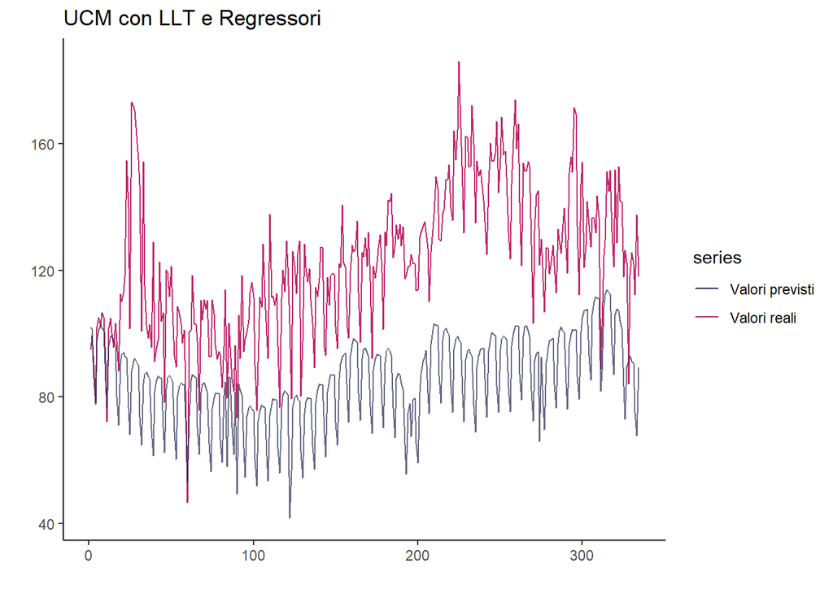

```r
ucm_LLT_graph <- ggplot() +
                 autolayer(ts(valid), series="Valori reali",size=0.4) +
                 autolayer(ts(ucm_pred, start=start(ts(valid)),
                      frequency=frequency(ts(valid))),
                      series="Valori previsti", size=0.4, alpha=0.7) +
                 xlab("") +
                 ylab("") +
                 ggtitle("UCM con LLT e Regressori") +
                 scale_color_manual(values = c("#252850", "#C12869")) +
                 theme_classic()

ucm_LLT_graph
```

### LLT senza regressori

```r
ucm_LLT_noreg <- SSModel(train ~ SSMtrend(2, list(NA,NA)) +
                    SSMseasonal(7, NA, "dummy") +
                    SSMseasonal(365, NA, "trig", harmonics = 1:20),
                    H = NA)

vary <- var(train, na.rm = TRUE)
ucm_LLT_noreg$P1inf <- ucm_LLT_noreg$P1inf * 0
ucm_LLT_noreg$a1[1] <- mean(train, na.rm = TRUE)
diag(ucm_LLT_noreg$P1) <- vary


init <- numeric(5)
init[1] <- log(vary/10)
init[2] <- log(vary/10)
init[3] <- log(vary/100)
init[4] <- log(vary/100)
init[5] <- log(vary/10)

update_fun <- function(pars, model){
    model$Q[1, 1, 1] <- exp(pars[1])
    model$Q[2, 2, 1] <- exp(pars[2])
    model$Q[3, 3, 1] <- exp(pars[3])
    diag(model$Q[4:43, 4:43, 1]) <- exp(pars[4])
    model$H[1, 1, 1] <- exp(pars[5])
    model
}

fit2 <- fitSSM(ucm_LLT_noreg, init, update_fun)
print(fit2$optim.out$convergence)
```

```
## [1] 0
```

```r
data <- c(rep(NA, 334))
temp_mod_noreg <- SSModel(data ~
                           SSMtrend(2, list(fit1$model$Q[1,1,1],fit1$model$Q[2,2,1])) +
                           SSMseasonal(7, fit1$model$Q[3,3,1], "dummy") +
                           SSMseasonal(365, fit1$model$Q[4, 4, 1], "trig",
                           harmonics = 1:20),
                           H = fit2$model$H)

ucm_pred <- predict(fit2$model, newdata=temp_mod_noreg)[1:334]
valid <- as.numeric(df_validation)[1:334]

score_LLT_noreg <- c(mean(abs(ucm_pred - valid)/valid))

for (i in 1:(length(df_validation) - 334)){
    data <- c(as.numeric(df_validation[1:i]), rep(NA, 334))
    temp_mod_noreg <- SSModel(data ~ SSMtrend(2, list(fit2$model$Q[1,1,1],fit2$model$Q[2,2,1])) +
                      SSMseasonal(7, fit2$model$Q[3,3,1], "dummy") +
                      SSMseasonal(365, fit2$model$Q[4, 4, 1], "trig",
                                  harmonics = 1:20),
                    H = fit2$model$H)
    ucm_pred <- predict(fit2$model, newdata=temp_mod_noreg)[(i+1):(i+334)]
    valid <- as.numeric(df_validation)[(i+1):(i+334)]
    score_LLT_noreg <- c(score_LLT_noreg,mean(abs(ucm_pred - valid)/valid))
}

score_LLT_noreg <- mean(score_LLT_noreg)*100
print(score_LLT_noreg)
```

```
## [1] 18.68434
```

```r
score_train_LLT_no_reg <- mean(abs(fitted(fit2$model) - as.numeric(train))/as.numeric(train)) * 100
score_train_LLT_no_reg
```

```
## [1] 7.494406
```

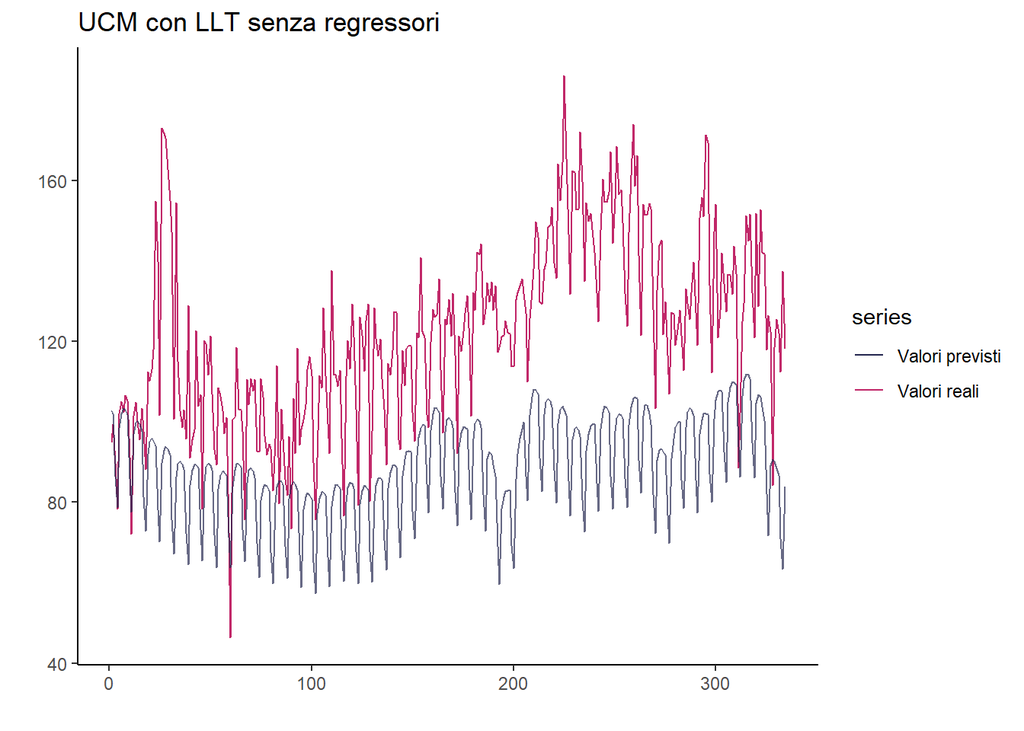

```r
ucm_LLT_noreg_graph <- ggplot() +
                 autolayer(ts(valid), series="Valori reali",size=0.4) +
                 autolayer(ts(ucm_pred, start=start(ts(valid)),
                      frequency=frequency(ts(valid))),
                      series="Valori previsti", size=0.4, alpha=0.7) +
                 xlab("") +
                 ylab("") +
                 ggtitle("UCM con LLT senza regressori") +
                 scale_color_manual(values = c("#252850", "#C12869")) +
                 theme_classic()

ucm_LLT_noreg_graph
```

### Random walk

```r
ucm_RW <- SSModel(train ~ SSMtrend(1, NA) +
                      SSMseasonal(7, NA, "dummy") +
                      SSMseasonal(365, NA, "trig",
                                  harmonics = 1:20),
                H = NA)

vary <- var(train, na.rm = TRUE)
ucm_RW$P1inf <- ucm_RW$P1inf * 0
ucm_RW$a1[1] <- mean(train, na.rm = TRUE)
diag(ucm_RW$P1) <- vary

init <- numeric(5)
init[1] <- log(vary/10)
init[2] <- log(vary/100)
init[3] <- log(vary/100)
init[4] <- log(vary/10)

#funzione per fitSSM
update_fun <- function(pars, model){
    model$Q[1, 1, 1] <- exp(pars[1])
    model$Q[2, 2, 1] <- exp(pars[2])
    diag(model$Q[3:42, 3:42, 1]) <- exp(pars[3])
    model$H[1, 1, 1] <- exp(pars[4])
    model
}

fit3 <- fitSSM(ucm_RW, init, update_fun)
print(fit3$optim.out$convergence)
```

```
## [1] 0
```

```r
data <- c(rep(NA, 334))
temp_mod <- SSModel(data ~  SSMtrend(1, fit3$model$Q[1,1,1]) +
                              SSMseasonal(7, fit3$model$Q[2,2,1], "dummy") +
                              SSMseasonal(365, fit3$model$Q[3, 3, 1], "trig",
                              harmonics = 1:20),
                    H = fit3$model$H)
ucm_RW_pred <- predict(fit3$model, newdata=temp_mod)[1:334]
valid <- as.numeric(df_validation)[1:334]

score_RW <- c(mean(abs(ucm_RW_pred - valid)/valid))

for (i in 1:(length(df_validation) - 334)){
    data <- c(as.numeric(df_validation[1:i]), rep(NA, 334))
    temp_mod <- SSModel(data ~  SSMtrend(1, fit3$model$Q[1,1,1]) +
                          SSMseasonal(7, fit3$model$Q[2,2,1], "dummy") +
                          SSMseasonal(365, fit3$model$Q[3, 3, 1], "trig",
                              harmonics = 1:20),
                        H = fit3$model$H)
    ucm_RW_pred <- predict(fit3$model, newdata=temp_mod)[(i+1):(i+334)]
    valid <- as.numeric(df_validation)[(i+1):(i+334)]
    score_RW <- c(score_RW,mean(abs(ucm_RW_pred - valid)/valid))
}

score_RW <- mean(score_RW)*100
print(score_RW)
```

```
## [1] 17.26546
```

```r
score_train_RW <- mean(abs(fitted(fit3$model) - as.numeric(train))/as.numeric(train)) * 100
score_train_RW
```

```
## [1] 7.596296
```

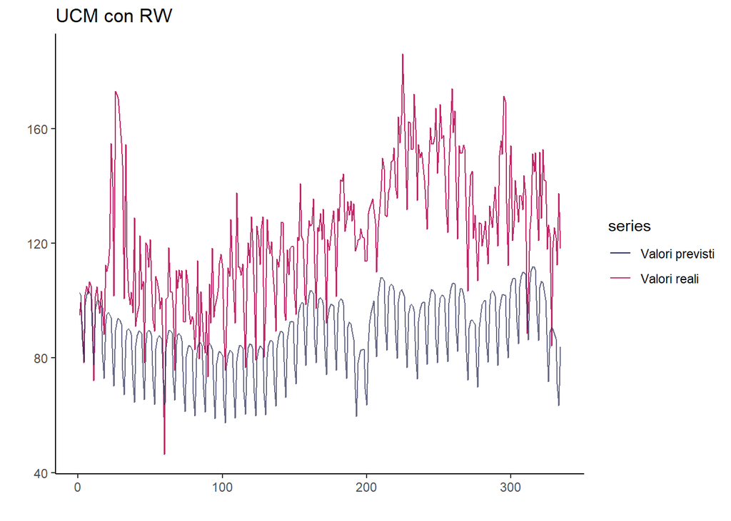

```r
ucm_RW_graph <- ggplot() +
                 autolayer(ts(valid), series="Valori reali",size=0.4) +
                 autolayer(ts(ucm_pred, start=start(ts(valid)),
                      frequency=frequency(ts(valid))),
                      series="Valori previsti", size=0.4, alpha=0.7) +
                 xlab("") +
                 ylab("") +
                 ggtitle("UCM con RW") +
                 scale_color_manual(values = c("#252850", "#C12869")) +
                 theme_classic()

ucm_RW_graph
```

### Integrated Random Walk

```r
ucm_mod_IRW <- SSModel(train ~ SSMtrend(2, list(0,NA)) +
                      SSMseasonal(7, NA, "dummy") +
                      SSMseasonal(365, NA, "trig",
                                  harmonics = 1:20),
                H = NA)

vary <- var(train, na.rm = TRUE)
ucm_mod_IRW$P1inf <- ucm_mod_IRW$P1inf * 0
ucm_mod_IRW$a1[1] <- mean(train, na.rm = TRUE)
diag(ucm_mod_IRW$P1) <- vary



#valori iniziali delle varianze
init <- numeric(5)
init[1] <- 0
init[2] <- log(vary/10)
init[3] <- log(vary/100)
init[4] <- log(vary/100)
init[5] <- log(vary/10)

#funzione per fitSSM
update_fun <- function(pars, model){
    model$Q[1, 1, 1] <- exp(pars[1])
    model$Q[2, 2, 1] <- exp(pars[2])
    model$Q[3, 3, 1] <- exp(pars[3])
    diag(model$Q[4:43, 4:43, 1]) <- exp(pars[4])
    model$H[1, 1, 1] <- exp(pars[5])
    model
}

fit4 <- fitSSM(ucm_mod_IRW, init, update_fun)
print(fit4$optim.out$convergence)
```

```
## [1] 0
```

```r
data <- c(rep(NA, 334))
temp_mod <- SSModel(data ~  SSMtrend(2, list(0,fit4$model$Q[2,2,1])) +
                      SSMseasonal(7, fit4$model$Q[3,3,1], "dummy") +
                      SSMseasonal(365, fit4$model$Q[4, 4, 1], "trig",
                              harmonics = 1:20),
                    H = fit4$model$H)
ucm_pred_IRW <- predict(fit4$model, newdata=temp_mod)[1:334]
valid <- as.numeric(df_validation)[1:334]

score_IRW <- c(mean(abs(ucm_pred_IRW - valid)/valid))

for (i in 1:(length(df_validation) - 334)){
    data <- c(as.numeric(df_validation[1:i]), rep(NA, 334))
    temp_mod <- SSModel(data ~ SSMtrend(2, list(0,fit4$model$Q[2,2,1])) +
                      SSMseasonal(7, fit4$model$Q[3,3,1], "dummy") +
                      SSMseasonal(365, fit4$model$Q[4, 4, 1], "trig",
                                  harmonics = 1:20),
                    H = fit4$model$H)
    ucm_pred_IRW <- predict(fit4$model, newdata=temp_mod)[(i+1):(i+334)]
    valid <- as.numeric(df_validation)[(i+1):(i+334)]
    score_IRW <- c(score_IRW,mean(abs(ucm_pred_IRW - valid)/valid))
}

score_IRW<- mean(score_IRW)*100
print(score_IRW)
```

```
## [1] 16.7428
```

```r
score_train_IRW <- mean(abs(fitted(fit4$model) - as.numeric(train))/as.numeric(train)) * 100
score_train_IRW
```

```
## [1] 7.49373
```

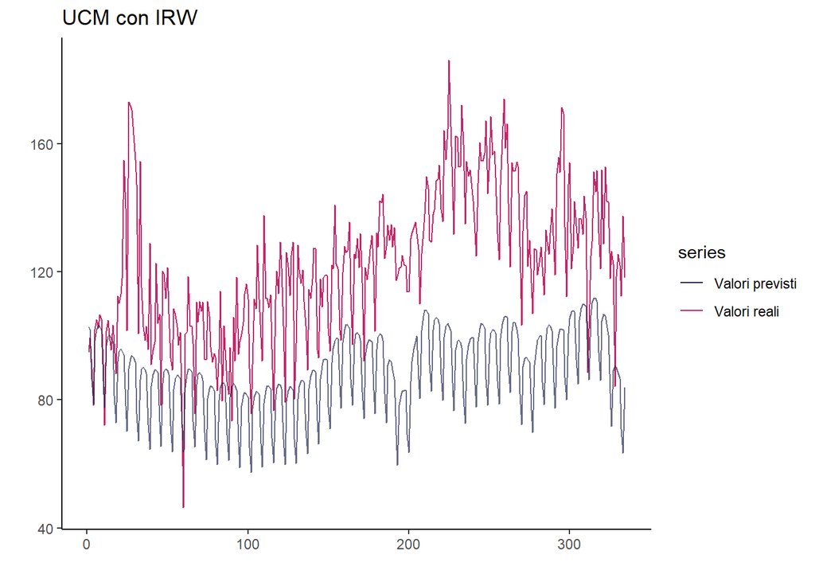

```r
ucm_IRW_graph <- ggplot() +
                 autolayer(ts(valid), series="Valori reali",size=0.4) +
                 autolayer(ts(ucm_pred, start=start(ts(valid)),
                      frequency=frequency(ts(valid))),
                      series="Valori previsti", size=0.4, alpha=0.7) +
                 xlab("") +
                 ylab("") +
                 ggtitle("UCM con IRW") +
                 scale_color_manual(values = c("#252850", "#C12869")) +
                 theme_classic()

ucm_IRW_graph
```

```r
print(paste0("MAPE UCM model with LLT with regressors on train: ", round(score_train_LLT_reg, 2)))
```

```
## [1] "MAPE UCM model with LLT with regressors on train: 7.11"
```

```r
print(paste0("MAPE UCM model with LLT without regressors on train: ", round(score_train_LLT_no_reg, 2)))
```

```
## [1] "MAPE UCM model with LLT without regressors on train: 7.49"
```

```r
print(paste0("MAPE UCM model with RW on train: ", round(score_train_RW, 2)))
```

```
## [1] "MAPE UCM model with RW on train: 7.6"
```

```r
print(paste0("MAPE UCM model with IRW on train: ", round(score_train_IRW, 2)))
```

```
## [1] "MAPE UCM model with IRW on train: 7.49"
```

```r
print(paste0("MAPE UCM model with LLT with regressors on validation: ", round(score_LLT_reg, 2)))
```

```
## [1] "MAPE UCM model with LLT with regressors on validation: 19.06"
```

```r
print(paste0("MAPE UCM model with LLT without regressors on validation: ", round(score_LLT_noreg, 2)))
```

```
## [1] "MAPE UCM model with LLT without regressors on validation: 18.68"
```

```r
print(paste0("MAPE UCM model with RW on validation: ", round(score_RW, 2)))
```

```
## [1] "MAPE UCM model with RW on validation: 17.27"
```

```r
print(paste0("MAPE UCM model with IRW on validation: ", round(score_IRW,2)))
```

```
## [1] "MAPE UCM model with IRW on validation: 16.74"
```

```r
#gridExtra::grid.arrange(ucm_LLT_graph, ucm_LLT_noreg_graph, ucm_RW_graph, ucm_IRW_graph, ncol = 2)
```

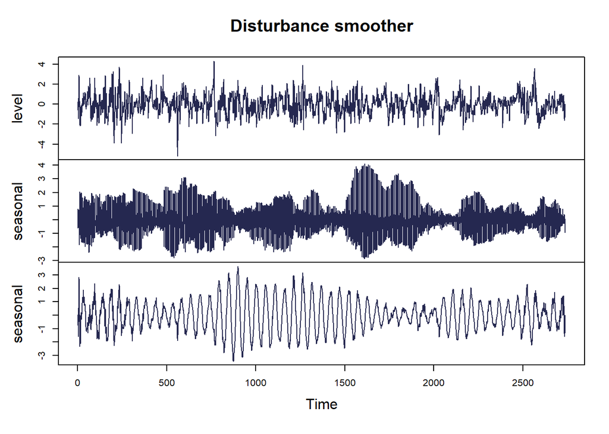

```r
smo3 <- KFS(fit3$model,
            smoothing = c("disturbance",
                          "signal"))

dist3 <- rstandard(smo3, "state")
# si selezionano l'errore dell'evoluzione del livello, dello slope e di una stagionalità
plot(dist3[,c(1,2,15)], main= "Disturbance smoother", col="#252850")
```

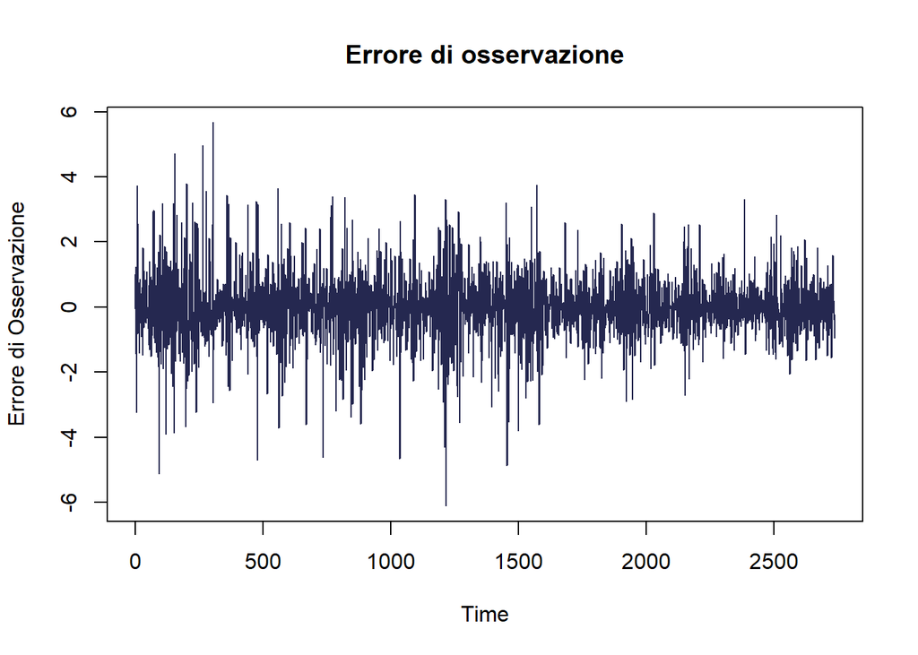

```r
err_oss <- rstandard(smo3, "pearson")
plot(err_oss, main = "Errore di osservazione", ylab = "Errore di Osservazione", col= "#252850")
```

In quest’ultimo grafico vengono visualizzate qualche osservazione anomala poiché fuori dalle bande in corrispondenza di +3/-3. Siccome sono un numero relativamente basso di osservazioni, non è necessaria la creazione di dummy utili a modellare gli shock.

### Previsione del modello UCM

```r
train <- df[, -c(3,4)]
test <- data.frame(Data=seq(as.Date("2019-01-01"), as.Date("2019-11-30"), by="day"), value=NA)
ucm_test <- rbind(train, test)
df_train_ucm <- xts(ucm_test$value, order.by = ucm_test$Data)
```

```r
df_train_ucm <- as.numeric(df_train_ucm)

best_ucm <- SSModel(df_train_ucm ~ SSMtrend(2, list(0,NA)) +
                      SSMseasonal(7, NA, "dummy") +
                      SSMseasonal(365, NA, "trig",
                                  harmonics = 1:20),
                H = NA)

vary <- var(df_train_ucm, na.rm = TRUE)
best_ucm$P1inf <- best_ucm$P1inf * 0
best_ucm$a1[1] <- mean(df_train_ucm, na.rm = TRUE)
diag(best_ucm$P1) <- vary



#valori iniziali delle varianze
init <- numeric(5)
init[1] <- 0
init[2] <- log(vary/10)
init[3] <- log(vary/100)
init[4] <- log(vary/100)
init[5] <- log(vary/10)

#funzione per fitSSM
update_fun <- function(pars, model){
    model$Q[1, 1, 1] <- exp(pars[1])
    model$Q[2, 2, 1] <- exp(pars[2])
    model$Q[3, 3, 1] <- exp(pars[3])
    diag(model$Q[4:43, 4:43, 1]) <- exp(pars[4])
    model$H[1, 1, 1] <- exp(pars[5])
    model
}

fit_finale <- fitSSM(best_ucm, init, update_fun, control = list(maxit = 1000))
print(fit_finale$optim.out$convergence)
```

```
## [1] 0
```

```r
smo_best_mod <- KFS(fit_finale$model,
            filtering = "signal")

ucm_test_value <- smo_best_mod$m[(length(df_train_ucm)-333):length(df_train_ucm)]
```

## Modelli non lineari

### KNN

```r
ts <- ts(df$value, frequency = 7)
ts_train = ts[1:2738]
ts_test = ts[2739:3287]
```

```r
d <- seq(5, 100, 5)
score <- c()

for (i in d){
    mod <- knn_forecasting(ts_train, h = 549, lags = 1:365, k = i, msas = "recursive")
    pred <- mod$pred
    single_score <- mean(abs(pred - ts_test)/ts_test)
    score <- append(score, single_score)

}
```

```r
#stima del modello migliore
mod <- knn_forecasting(ts_train, h = 549, lags = 1:365,  k = 35, msas = "recursive")
pred <- mod$pred
score_mod <- mean(abs(pred - ts_test)/ts_test)
paste0("MAPE KNN con k=35: ", round(score_mod, 4))
```

```
## [1] "MAPE KNN con k=35: 0.1595"
```

### LSTM

```r
time_series_dataset <- read.csv("C:/Users/FedericaFiorentini/Desktop/time_series_dataset.csv", sep=";")

time_series_dataset$Data = as.Date(time_series_dataset$Data)

time_series_dataset1 <- time_series_dataset[-c(759, 2551),]

df_train <- time_series_dataset1[1:2555,]
df_val <- time_series_dataset1[2556:3285,]

df <- bind_rows(
    df_train %>% add_column(key = "training"),
    df_val %>% add_column(key = "validation"))

rec_obj <- recipe(value ~ ., df) %>%
    step_sqrt(value) %>%
    step_center(value) %>%
    step_scale(value) %>%
    prep()

df_scaled <- bake(rec_obj, df)

center_history <- rec_obj$steps[[2]]$means["value"]
scale_history  <- rec_obj$steps[[3]]$sds["value"]

c("center" = center_history, "scale" = scale_history)
```

```
## center.value  scale.value
##    10.689379     1.435924
```

```r
batch_size   <- 365
tsteps       <- 1
epochs       <- 200

# Training
train_lag <- df_scaled %>%
    mutate(value_lag = lag(value, 365)) %>%
    filter(!is.na(value_lag)) %>%
    filter(key == "training")


x_train <- array(data = train_lag$value_lag, dim = c(length(train_lag$value_lag), tsteps, 1))

y_train <- array(data = train_lag$value, dim = c(length(train_lag$value), tsteps))

# Validation
val_lag <- df_scaled%>%
    mutate(value_lag = lag(value, 365)) %>%
    filter(!is.na(value_lag)) %>%
    filter(key == "validation")

x_val <- array(data = val_lag$value_lag, dim = c(length(val_lag$value_lag), tsteps, 1))

y_val <- array(data = val_lag$value, dim = c(length(val_lag$value), tsteps))
```

```r
mod_lstm1 <- keras_model_sequential()

mod_lstm1 %>%
    layer_lstm(units            = 90,
               input_shape      = c(tsteps, 1),
               batch_size       = batch_size,
               return_sequences = TRUE,
               stateful         = TRUE) %>%
    layer_lstm(units            = 90,
               return_sequences = FALSE,
               stateful         = TRUE) %>%
    layer_dense(units = 1)

mod_lstm1 %>%
    compile(loss = 'mae', optimizer = 'adam')

mod_lstm1
```

```
## Model
## ________________________________________________________________________________
## Layer (type)                        Output Shape                    Param #
## ================================================================================
## lstm (LSTM)                         (365, 1, 90)                    33120
## ________________________________________________________________________________
## lstm_1 (LSTM)                       (365, 90)                       65160
## ________________________________________________________________________________
## dense (Dense)                       (365, 1)                        91
## ================================================================================
## Total params: 98,371
## Trainable params: 98,371
## Non-trainable params: 0
## ________________________________________________________________________________
```

```r
for (i in 1:epochs) {
    mod_lstm1 %>% fit(x= x_train,
                  y = y_train,
                  batch_size = batch_size,
                  epochs     = 1,
                  verbose    = 1,
                  shuffle    = FALSE)
    cat("Epoch: ", i)}
```

[output not shown]

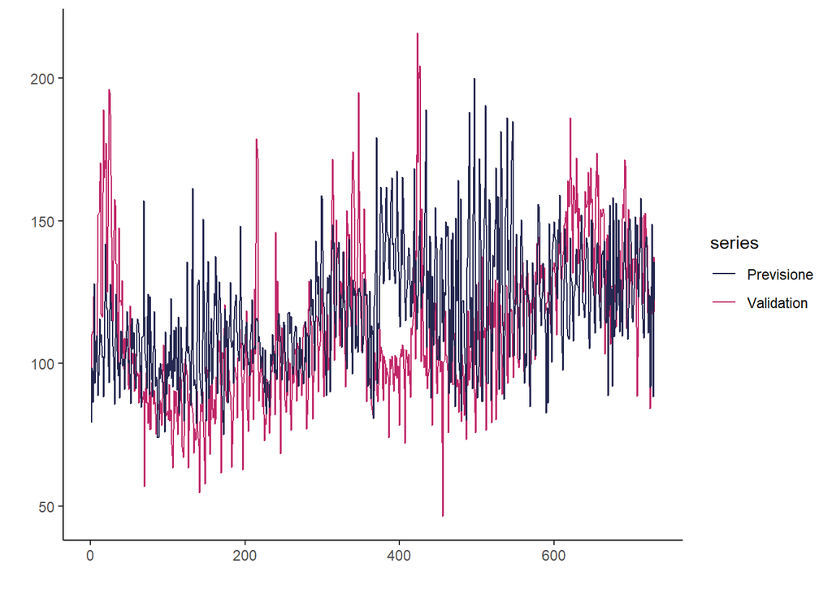

```r
pred_lstm1_scaled<- mod_lstm1 %>%
    predict(x_val, batch_size = batch_size) %>%
    .[,1]

# Trasformazione inversa
pred_lstm1 <- tibble(
    Data   = val_lag$Data,
    value   = (pred_lstm1_scaled * scale_history + center_history)^2)


ggplot() +
  autolayer(ts(df_val$value), series="Validation",size=0.4) +
  autolayer(ts(pred_lstm1$value),
                  series="Previsione", size=0.4)+
  xlab("") +
  ylab("")+
  scale_color_manual(values = c("#252850", "#C12869"))+
  theme_classic()
```

```r
mape_lstm1 <- mean(abs(as.numeric(pred_lstm1$value) - as.numeric(df_val$value))/as.numeric(df_val$value))
mape_lstm1
```

```
## [1] 0.2177463
```

### GRU

```r
mod_gru1 <- keras_model_sequential()

mod_gru1 %>%
    layer_gru(units  = 90,
               input_shape = c(tsteps, 1),
               batch_size  = batch_size,
              dropout=0.3, recurrent_dropout=0.5) %>%
    layer_dense(units = 1, activation = "linear")

mod_gru1 %>%
    compile(loss = 'mae', optimizer = 'adam') #adam

mod_gru1
```

```
## Model
## ________________________________________________________________________________
## Layer (type)                        Output Shape                    Param #
## ================================================================================
## gru (GRU)                           (365, 90)                       24840
## ________________________________________________________________________________
## dense_1 (Dense)                     (365, 1)                        91
## ================================================================================
## Total params: 24,931
## Trainable params: 24,931
## Non-trainable params: 0
## ________________________________________________________________________________
```

```r
for (i in 1:epochs) {
    mod_gru1 %>% fit(x  = x_train,
                  y    = y_train,
                  batch_size = batch_size,
                  epochs     = 1,
                  verbose    = 1,
                  shuffle    = FALSE)

    cat("Epoch: ", i)

}
```

[output not shown]

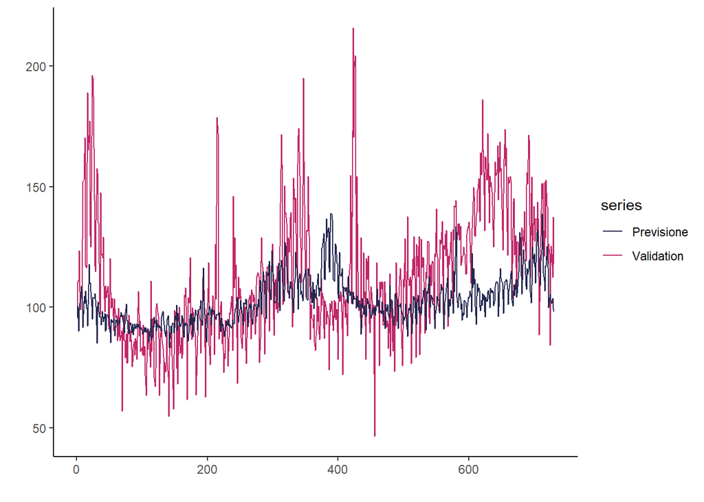

```r
pred_gru1_scaled <- mod_gru1 %>%
    predict(x_val, batch_size = batch_size) %>%
    .[,1]

# Trasformazione inversa
pred_gru1 <- tibble(
    Data   = val_lag$Data,
    value   = (pred_gru1_scaled * scale_history + center_history)^2)


ggplot() +
  autolayer(ts(df_val$value), series="Validation",size=0.4) +
  autolayer(ts(pred_gru1$value),
                  series="Previsione", size=0.4)+
  xlab("") +
  ylab("")+
  scale_color_manual(values = c("#252850", "#C12869"))+
  theme_classic()
```

```r
# MAPE validation
mape_gru1 <- mean(abs(as.numeric(pred_gru1$value) - as.numeric(df_val$value))/as.numeric(df_val$value))
mape_gru1
```

```
## [1] 0.1619392
```